# Unsupervised analysis I

September 28, 2015

## A rough dichomotomy of data analysis

In approximate order of difficulty

- **Descriptive**
- **Exploratory**
- *Inferential*
- *Predictive*
- *Causal*
- *Mechanistic*

**Unsupervised** *Supervised*

## Supervised versus unsupervised

**Supervised**

- You have an outcome \(Y\) and some covariates \(X\)
- You typically want to solve something like \(argmin_f E\left[(Y-f(X))^2\right]\)

**Unsupervised**

- You have a bunch of observations \(X\) and you want to understand the relationships between them.
- You are usually trying to understand patterns in \(X\) or group the variables in \(X\) in some way

## Semi-supervised

- Things like "deep learning" - http://en.wikipedia.org/wiki/Deep_learning
- Two cool examples: [Cat recognizer from Youtube videos](http://static.googleusercontent.com/media/research.google.com/en/us/archive/unsupervised_icml2012.pdf), [Learning to sing like a bird](http://people.csail.mit.edu/mhcoen/Papers/birdsong.pdf)
- I liked this guide [Neural networks and deep learning](http://neuralnetworksanddeeplearning.com/)

## A few techniques for unsupervised analysis

- Kernel density estimation
- Clustering
- Principal components analysis/svd
- Factor analysis
- MDS/ICA/MFPCA/…

## Estimating a univariate density

You have some data

```r
library(bootstrap)
data(stamp)
str(stamp)
```

```
## 'data.frame':    485 obs. of  1 variable:
##  $ Thickness: num  0.06 0.064 0.064 0.065 0.066 0.068 0.069 0.069 0.069 0.069 ...
```

```r
thick = stamp$Thickness
```

You want to know what this distribution looks like.

## You could calculate summary statistics

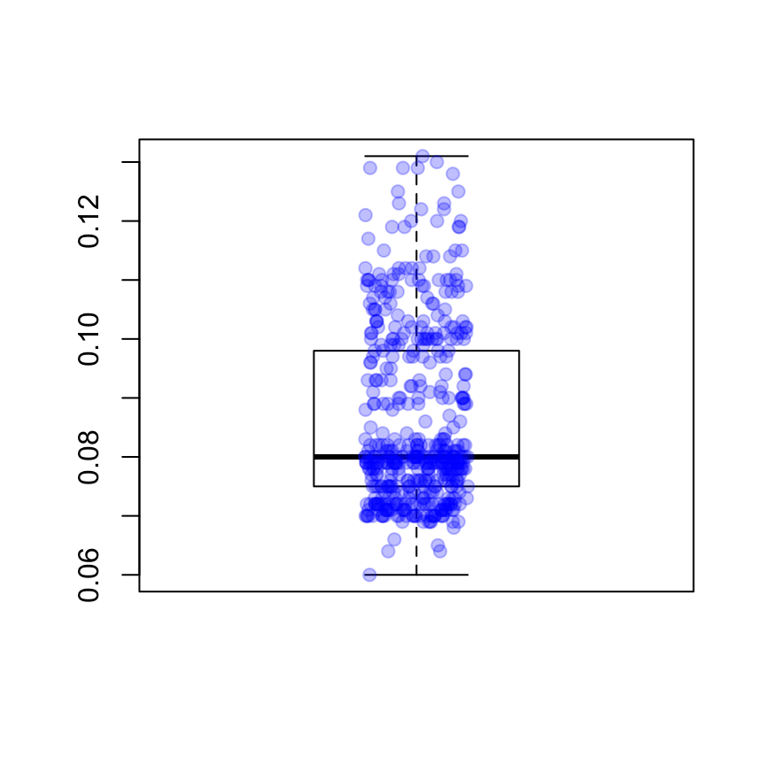

```r
boxplot(thick)
stripchart(thick,add=T,vertical=T,jitter=0.1,method="jitter",pch=19,col=rgb(0,0,1,0.25))
```

## Binning

\(X_1,\ldots,X_n \sim F\) with density \(f(\cdot)\) and you want an estimator \(\hat{f}\)

First idea - bin the data. In math this is what this looks like:

\[I_j = (x_0 + j\times h,x_0+(j+1)\times h],j=-1,0,1,\ldots\]

Calculate counts in bins

\[C_j = \sum_{i=1}^n I(x_i \in I_j)\]

Parameters are \(x_0\), \(h\).

## You've seen this

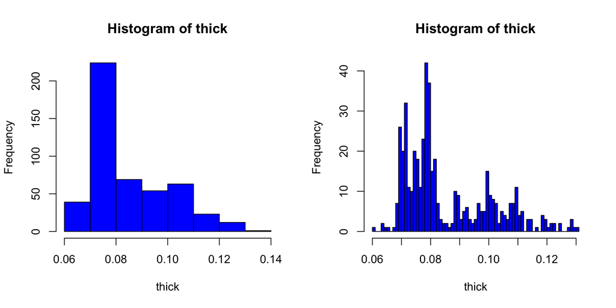

```r
par(mfrow=c(1,2))
hist(thick,col="blue"); hist(thick,breaks=100,col="blue")
```

## Estimating the density

Suppose you want an actual estimate of \(f(\cdot)\), then we need to estimate probability of being in a bin.

\[\hat{f}(x) = \frac{1}{2hn} \#\{i; X_i \in (x-h,x+h]\}\]

You can think of this as an approximation to this representation of the density:

\[f(x) = \lim_{h \rightarrow 0} \frac{1}{2h} \mathbb{P}[x-h < X \leq x+h]\]

This should look familiar, we are just replacing limits/expectations/etc with their empirical counterparts.

## The kernel density estimator

\[\hat{f}(x) = \frac{1}{2hn} \#\{i; X_i \in (x-h,x+h]\}\]

can be written as

\[ \hat{f}(x) = \frac{1}{nh} \sum_{i=1}^n w \left(\frac{x-X_i}{h}\right)\]

\[ w(x) = \left\{ \begin{array}{lr} 1/2 & if |x| < 1 \\ 0 & else\end{array}\right.\]

In general you can can write a kernel smoother as:

\[ \hat{f}(x) = \frac{1}{nh} \sum_{i=1}^n K\left(\frac{x-X_i}{h}\right)\]

where \(\int K(x) dx =1\) (this guarantees that \(\int \hat{f}(x) dx = 1\)) and \(h\) is the bandwidth.

## About the kernel and bandwidth

- The bandwidth can be chosen in a large number of ways
- Typically it is automatically chosen (e.g. in statistical software)
- Popular kernels add more weight to nearby points:
- \(K_{\lambda}(x_0,x_i) = D\left(\frac{|x_0 -x_i|}{\lambda}\right)\); \(D(t) = (2\pi)^{-1/2}e^{-t^2/2}\) (Gaussian)
- \(K_{\lambda}(x_0,x_i) = D\left(\frac{|x_0 -x_i|}{\lambda}\right)\); \(D(t) = (1-t^2)^2\) if \(t \leq 1\) (Tukey Biweight)

http://longor.public.iastate.edu/Stat516S13/slides/04.smoothing1.pdf

## The kernel density estimator

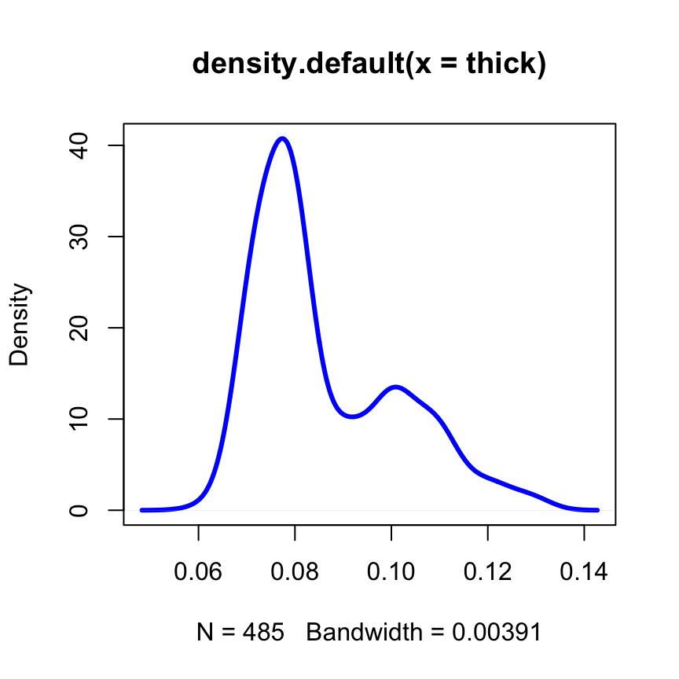

```r
dens = density(thick);
plot(dens,col="blue",lwd=3);
```

## Create our own KDE

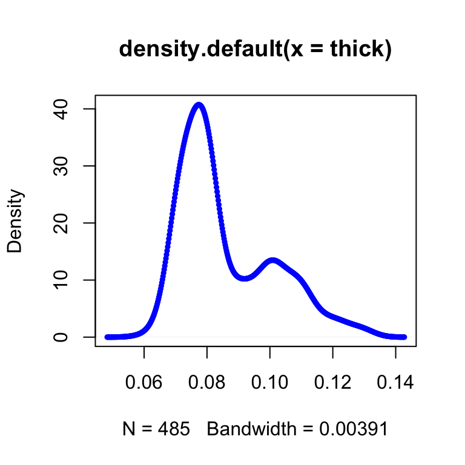

```r
dvals = rep(0,length(dens$x))
for(i in 1:length(thick)){
  dvals = dvals + dnorm(dens$x,mean=thick[i],sd=dens$bw)/length(thick)
}
plot(dens,col="red",lwd=3); points(dens$x,dvals,col="blue",pch=19,cex=0.5)
```

## Bias variance tradeoff

We often care about things like MSE:

\[ MSE(x) = \mathbb{E}\left[\left(\hat{f}(x) - f(x)\right)^2\right]\]

\[=\left(\mathbb{E}[\hat{f}(x)] - f(x)\right)^2 + {\rm Var}(\hat{f}(x))\]

- The bias of \(\hat{f}\) increases and the variance of \(\hat{f}\) decreases as \(h\) increases.
- This is the "bias variance" tradeoff in smoothing

## You can do this with supervised learning too

\[E_{\hat{F}}[Y|X=x_0] = {\rm a.v.e.} \{ y_i; x_i = x_0\}\]

- If the values of \(x_i\) are categorical we can estimate this directly.
- If not we need to "borrow strength"
- You've seen this before for linear regression

Define \(\{W_i(x)\}_{i=1}^{n}\) for each \(x\) and let

\[s(x) = \sum_{i=1}^n W_i(x) y_i\]

http://www.biostat.jhsph.edu/~ririzarr/Teaching/754/

## Why this works (intuitively)

\[ E[ Y | X ] = \int y f_{X,Y}(x,y) \, dy / f_X(x)\]

\[s(x) = \frac{ n^{-1}\sum_{i=1}^n K\left( \frac{x - x_i}{h} \right) y_i } { n^{-1}\sum_{i=1}^n K\left ( \frac{ x - x_i }{h} \right)}\]

Again we are basically just taking integrals and replacing them with sums. Noticing a theme here? Write down the theoretical parameter you are trying to estimate and then substitute empirical analogs.

http://www.biostat.jhsph.edu/~ririzarr/Teaching/754/

## Back to univariate smoothing for the moment

\[Bias(x) = \int K(z) (f(x-hz) - f(z))dz\]

\[Var(x) = n^{-1} \int \frac{1}{h^2} K\left(\frac{x-y}{h}\right)^2 f(y)dy - n^{-1} \left(\int \frac{1}{h}K\left(\frac{x-y}{h}\right)f(y)dy \right)^2\]

You can asymptotically minimize \(MSE(X)\) by solving \(\frac{\partial}{\partial h} MSE(x) = 0\)

You get something like this:

\[h_{opt} = n^{-1/5} \left(\frac{f(x)\int K^2(z)dz}{(f''(x)^2 (\int z^2 K(z)dz)^2)}\right)^{1/5}\]

Derivation: http://stat.ethz.ch/education/semesters/SS_2006/CompStat/sk-ch2.pdf

## Class exercises

1. What are some cases where density estimation might give you trouble?
2. How would we estimate the number of modes in a density estimate as a function of \(h\)?

## Answer to question 2

```r
nmodes <- function(y){
       x <- diff(y)
       n <- length(x)
       sum(x[2:n] < 0  & x[1:(n-1)] >  0)
}
```

## In higher dimensions

\(X_1, \ldots, X_n \sim f(x_1,\ldots,x_d)\)

We can estimate a multivariate smoother

\[ \hat{f}(x) = \frac{1}{nh^d} \sum_{i=1}^n K\left(\frac{x_i-X_i}{h}\right)\]

wher the kernel \(K(\cdot)\) is now a function on a d-dimensional vector satisfying

\(K(u) \geq 0\), \(\int_{\mathbb{R}^d} K(u)du = 1\), \(\int_{\mathbb{R}^d}uK(u)du = 0\) and \(\int_{\mathbb{R}^d} uu^T K(u)du = I_d\)

Usually you use a product kernel like \(K(u) = \prod_{j=1}^d k(u_j)\).

## Curse of dimensionality

Best possible MSE rate is \(O(n^{-4/(4+d)})\)

[figure not shown]

http://statweb.stanford.edu/~tibs/ElemStatLearn/

## Clustering

Clustering organizes things that are **close** into groups

- How do we define close?
- How do we group things?
- How do we visualize the grouping?
- How do we interpret the grouping?

## Hugely important/impactful

[figure not shown]

http://scholar.google.com/scholar?hl=en&q=cluster+analysis&btnG=&as_sdt=1%2C21&as_sdtp=

## Hierarchical clustering

- An agglomerative approach
- Find closest two things
- Put them together
- Find next closest
- Requires
- A defined distance
- A merging approach
- Produces
- A tree showing how close things are to each other

## How do we define close?

- Most important step
- Garbage in -> garbage out
- Distance or similarity
- Continuous - euclidean distance
- Continuous - correlation similarity
- Binary - manhattan distance
- Pick a distance/similarity that makes sense for your problem

## Example distances - Euclidean

[figure not shown]

http://rafalab.jhsph.edu/688/lec/lecture5-clustering.pdf

## Example distances - Euclidean

[figure not shown]

In general:

\[\sqrt{(A_1-A_2)^2 + (B_1-B_2)^2 + \ldots + (Z_1-Z_2)^2}\] http://rafalab.jhsph.edu/688/lec/lecture5-clustering.pdf

## Example distances - Manhattan

[figure not shown]

In general:

\[|A_1-A_2| + |B_1-B_2| + \ldots + |Z_1-Z_2|\]

http://en.wikipedia.org/wiki/Taxicab_geometry

## Hierarchical clustering - example

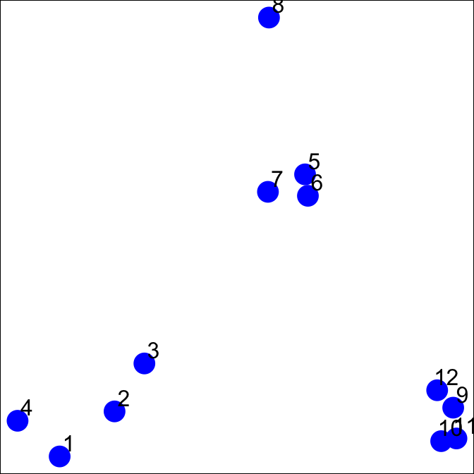

```r
set.seed(1234); par(mar=c(0,0,0,0))
x <- rnorm(12,mean=rep(1:3,each=4),sd=0.2)
y <- rnorm(12,mean=rep(c(1,2,1),each=4),sd=0.2)
plot(x,y,col="blue",pch=19,cex=2)
text(x+0.05,y+0.05,labels=as.character(1:12))
```

## Hierarchical clustering - `dist`

- Important parameters: *x*,*method*

```r
dataFrame <- data.frame(x=x,y=y)
dist(dataFrame)
```

```
##             1          2          3          4          5          6
## 2  0.34120511
## 3  0.57493739 0.24102750
## 4  0.26381786 0.52578819 0.71861759
## 5  1.69424700 1.35818182 1.11952883 1.80666768
## 6  1.65812902 1.31960442 1.08338841 1.78081321 0.08150268
## 7  1.49823399 1.16620981 0.92568723 1.60131659 0.21110433 0.21666557
## 8  1.99149025 1.69093111 1.45648906 2.02849490 0.61704200 0.69791931
## 9  2.13629539 1.83167669 1.67835968 2.35675598 1.18349654 1.11500116
## 10 2.06419586 1.76999236 1.63109790 2.29239480 1.23847877 1.16550201
## 11 2.14702468 1.85183204 1.71074417 2.37461984 1.28153948 1.21077373
## 12 2.05664233 1.74662555 1.58658782 2.27232243 1.07700974 1.00777231
##             7          8          9         10         11
## 2
## 3
## 4
## 5
## 6
## 7
## 8  0.65062566
## 9  1.28582631 1.76460709
## 10 1.32063059 1.83517785 0.14090406
## 11 1.37369662 1.86999431 0.11624471 0.08317570
## 12 1.17740375 1.66223814 0.10848966 0.19128645 0.20802789
```

## Hierarchical clustering - #1

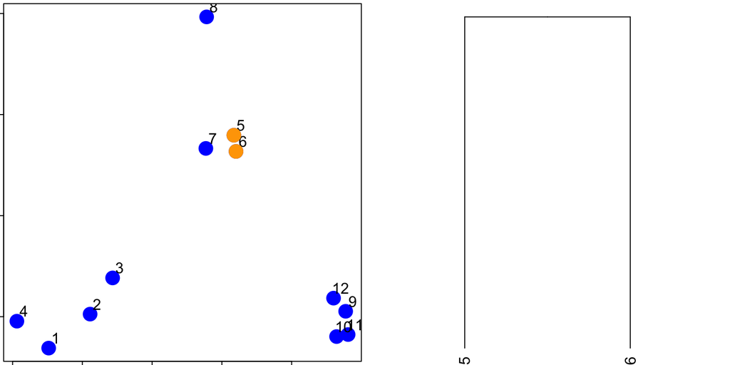

## Hierarchical clustering - #2

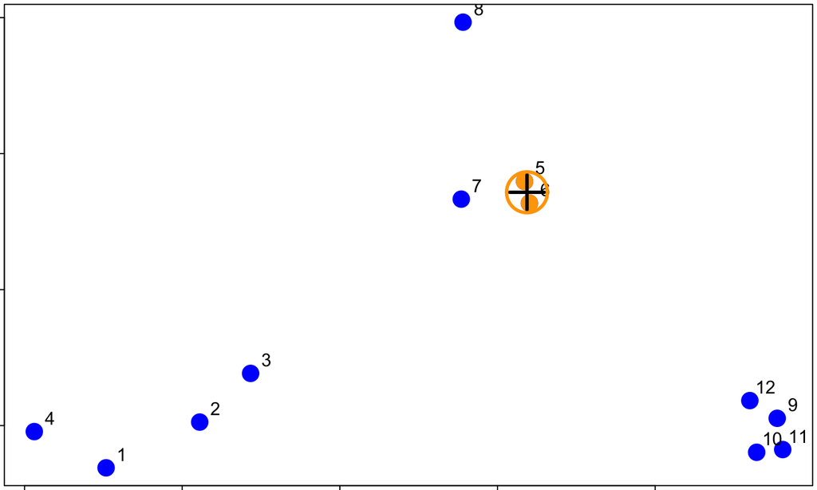

## Hierarchical clustering - #3

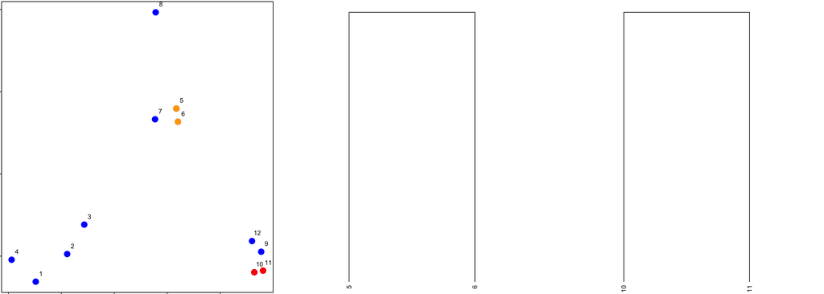

## Hierarchical clustering - hclust

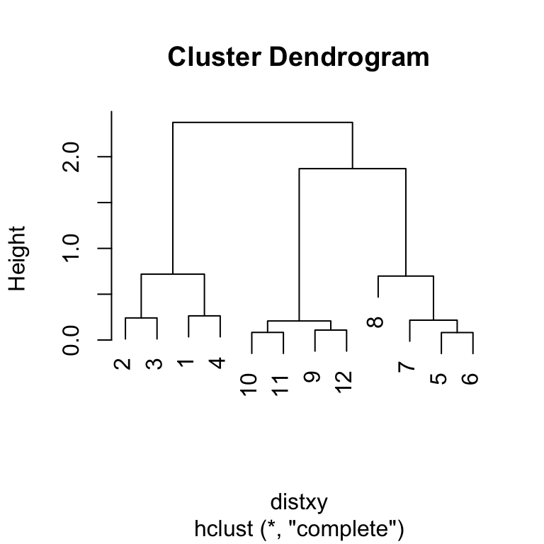

```r
dataFrame <- data.frame(x=x,y=y)
distxy <- dist(dataFrame)
hClustering <- hclust(distxy)
plot(hClustering)
```

## Prettier dendrograms

```r
myplclust <- function( hclust,
                       lab=hclust$labels,
                       lab.col=rep(1,length(hclust$labels)),
                       hang=0.1,...){
  y <- rep(hclust$height,2); x <- as.numeric(hclust$merge)
  y <- y[which(x<0)]; x <- x[which(x<0)]; x <- abs(x)
  y <- y[order(x)]; x <- x[order(x)]
  plot( hclust, labels=FALSE, hang=hang, ... )
  text( x=x, y=y[hclust$order]-(max(hclust$height)*hang),
        labels=lab[hclust$order], col=lab.col[hclust$order],
        srt=90, adj=c(1,0.5), xpd=NA, ... )
}
```

## Pretty dendrograms

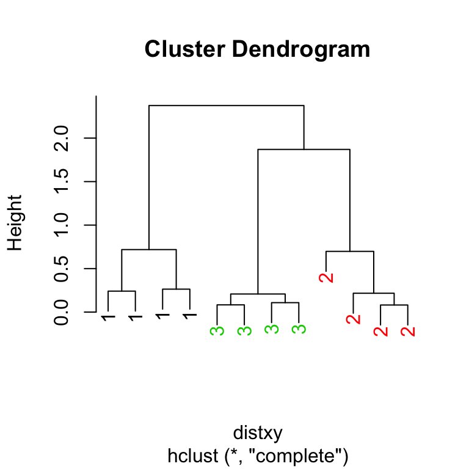

```r
dataFrame <- data.frame(x=x,y=y)
distxy <- dist(dataFrame)
hClustering <- hclust(distxy)
myplclust(hClustering,lab=rep(1:3,each=4),lab.col=rep(1:3,each=4))
```

## Even Prettier dendrograms

[figure not shown]

http://gallery.r-enthusiasts.com/RGraphGallery.php?graph=79

## Merging points - complete

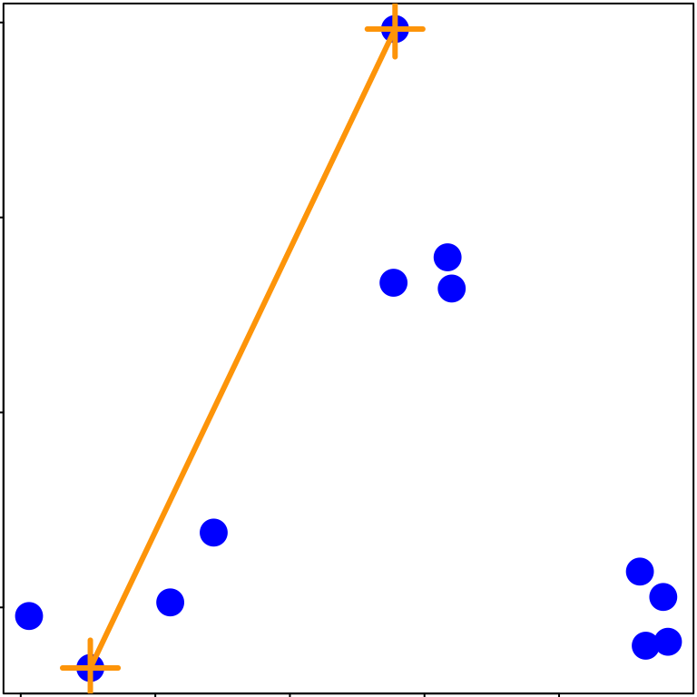

## Merging points - average

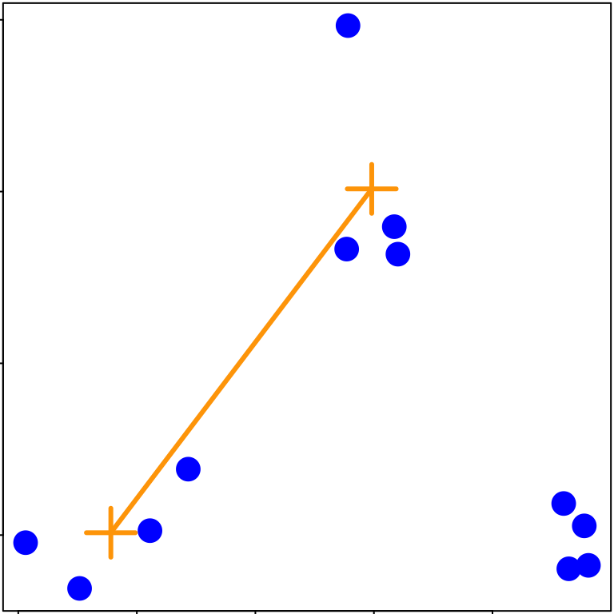

## `heatmap()`

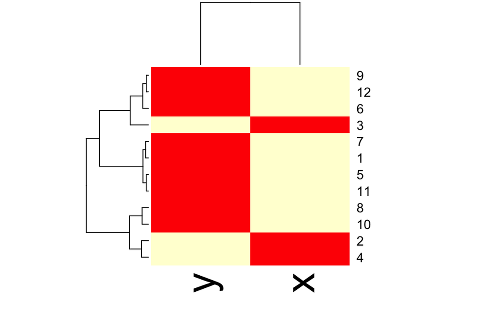

```r
dataFrame <- data.frame(x=x,y=y)
set.seed(143)
dataMatrix <- as.matrix(dataFrame)[sample(1:12),]
heatmap(dataMatrix)
```

## K-means clustering

- A partioning approach
  - Fix a number of clusters
  - Get "centroids" of each cluster
  - Assign things to closest centroid
  - Reclaculate centroids
- Requires
  - A defined distance metric
  - A number of clusters
  - An initial guess as to cluster centroids
- Produces
  - Final estimate of cluster centroids
  - An assignment of each point to clusters

## K-means clustering - example

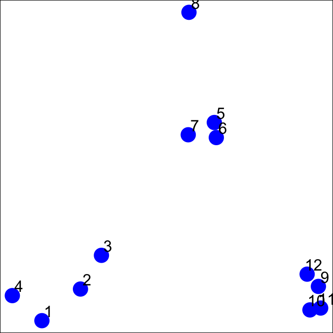

```r
set.seed(1234); par(mar=c(0,0,0,0))
x <- rnorm(12,mean=rep(1:3,each=4),sd=0.2)
y <- rnorm(12,mean=rep(c(1,2,1),each=4),sd=0.2)
plot(x,y,col="blue",pch=19,cex=2)
text(x+0.05,y+0.05,labels=as.character(1:12))
```

## K-means clustering - starting centroids

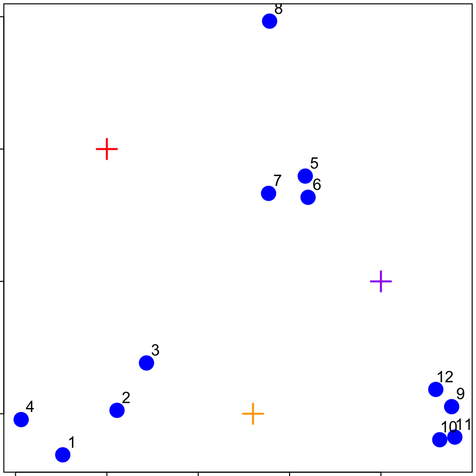

## K-means clustering - assign to closest centroid

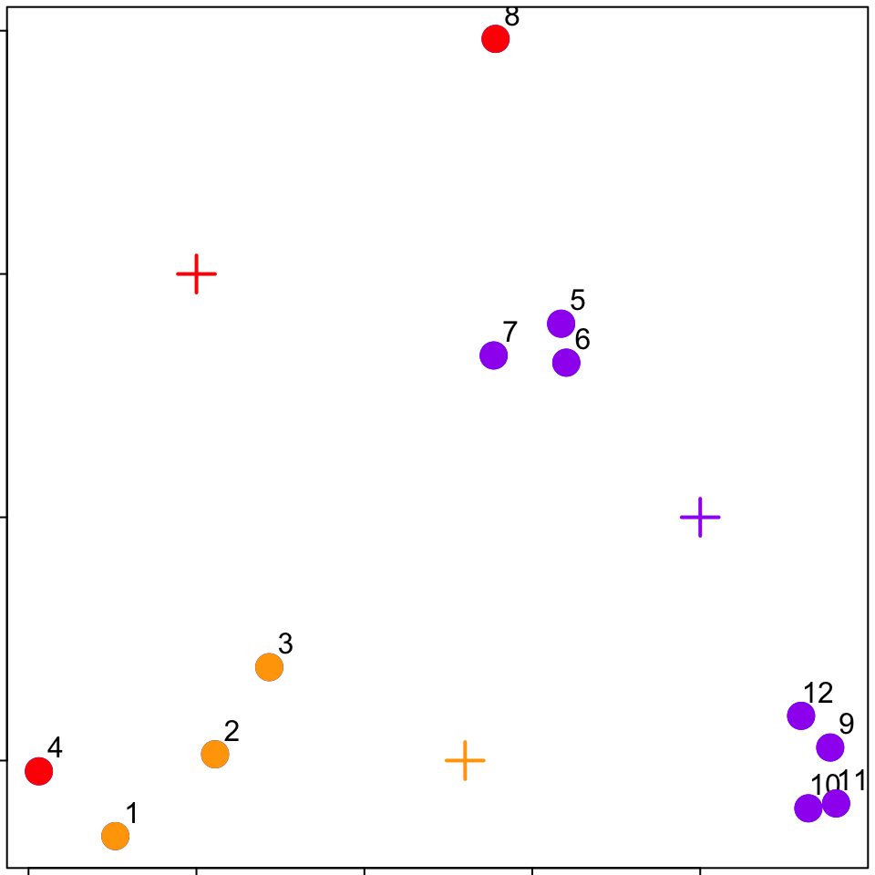

## K-means clustering - recalculate centroids

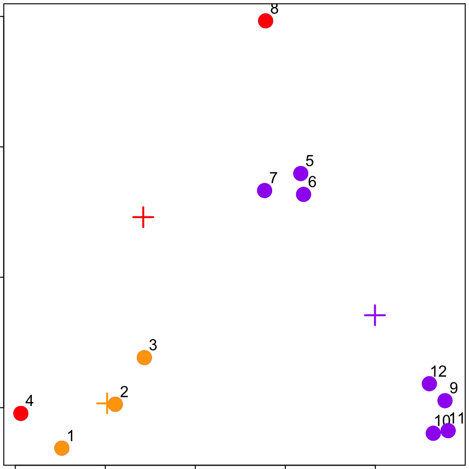

## K-means clustering - reassign values

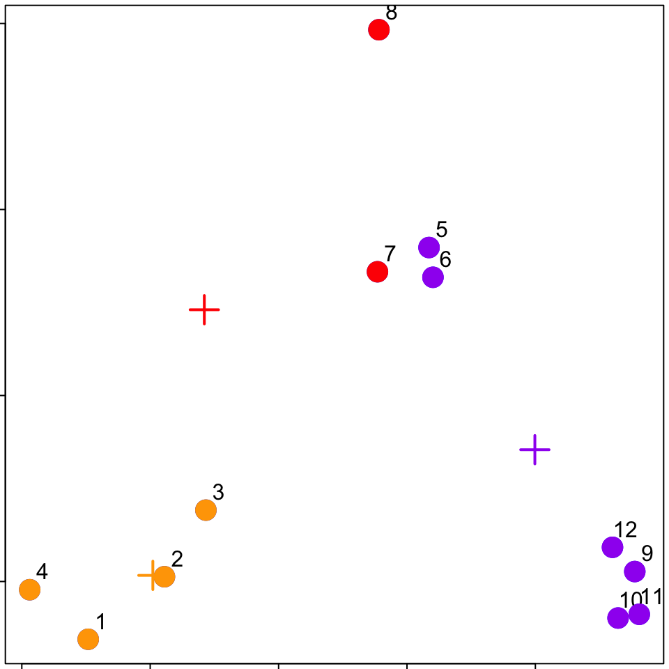

## K-means clustering - update centroids

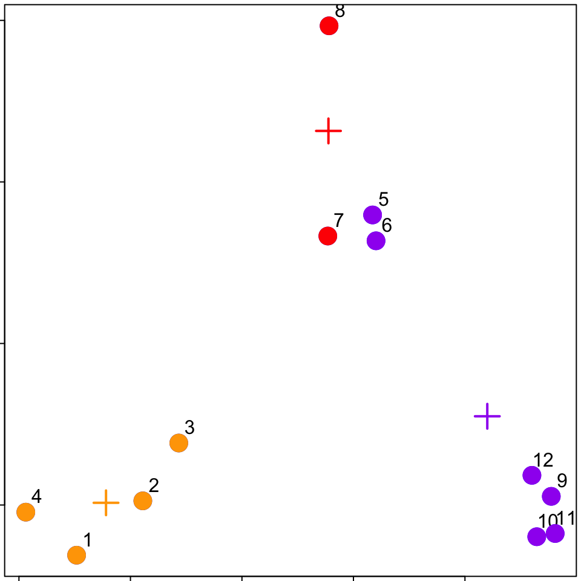

## `kmeans()`

- Important parameters: *x*, *centers*, *iter.max*, *nstart*

```r
dataFrame <- data.frame(x,y)
kmeansObj <- kmeans(dataFrame,centers=3)
names(kmeansObj)
```

```
## [1] "cluster"      "centers"      "totss"        "withinss"
## [5] "tot.withinss" "betweenss"    "size"         "iter"
## [9] "ifault"
```

```r
kmeansObj$cluster
```

```
##  [1] 3 3 3 3 1 1 1 1 2 2 2 2
```

## `kmeans()`

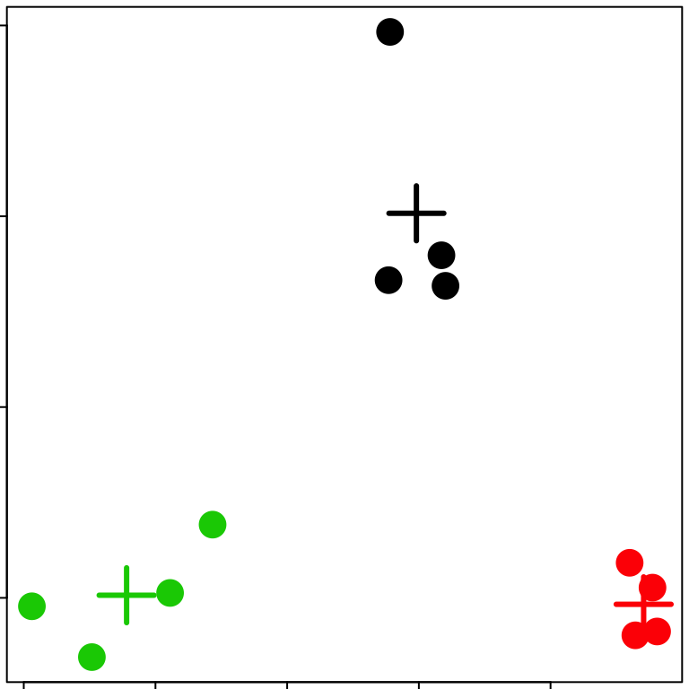

```r
par(mar=rep(0.2,4))
plot(x,y,col=kmeansObj$cluster,pch=19,cex=2)
points(kmeansObj$centers,col=1:3,pch=3,cex=3,lwd=3)
```

## Heatmaps

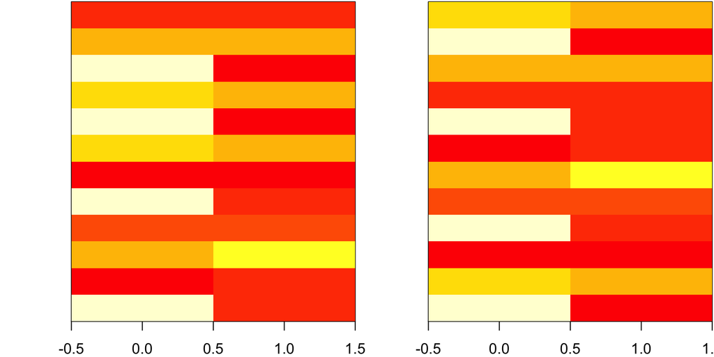

```r
set.seed(1234)
dataMatrix <- as.matrix(dataFrame)[sample(1:12),]
kmeansObj2 <- kmeans(dataMatrix,centers=3)
par(mfrow=c(1,2), mar = c(2, 4, 0.1, 0.1))
image(t(dataMatrix)[,nrow(dataMatrix):1],yaxt="n")
image(t(dataMatrix)[,order(kmeansObj$cluster)],yaxt="n")
```

## H-clustering aglomeration choices

Single

\[d_{SL}(G,H) = \min_{i\in G, i' \in H} d_{ii'}\]

Complete

\[d_{SL}(G,H) = \max_{i\in G, i' \in H} d_{ii'}\]

Average

\[d_{GA}(G,H) = \frac{1}{N_G N_H} \sum_{i \in G} \sum_{i' \in H} d_{ii'}\]

## What this looks like on real data

[figure not shown]

https://statistics.stanford.edu/~tibs/ElemStatLearn

## Consistency

Assuming that the data vector \(X_p \sim p_k(x)\) for some \(k=1,\ldots,K\) then as \(N \rightarrow \infty\)

\[d_{SL}(G,H) \rightarrow 0\] \[d_{CL}(G,H) \rightarrow \infty\] \[d_{GA}(G,H) \rightarrow \int \int d(x,x')p_{G}(x)p_{H}(x')dxdx'\]

## Another way to view clustering

[figure not shown]

- Can use plug-in estimate of the tree
- Piecewise constant in low dimensions
- Trouble with curse of dimensionality in large dimensions

http://www.stat.cmu.edu/~rnugent/teaching/CMU729/Lectures/NPClust.pdf

## K-means

Given initial clusters \(m^{(1)}_1,\ldots,m^{(1)}_k\) we iterate between:

**Assign each point to a cluster**

\[S_i^{(t)} = \left\{x_p: ||x_p - m_i^{(t)}||^2 \leq ||x_p - m_j^{(t)}||^2, \forall j\right\}\]

**Update means**

\[m_{i}^{(t+1)}=\frac{1}{|S_i^{(t)}|} \sum_{x_j \in S_i^{(t)}} x_j\]

Stop when the \(m_i\) have converged to local modes.

Similar to an [EM algorithm](http://en.wikipedia.org/wiki/Expectation%E2%80%93maximization_algorithm).

## K-means is matrix factorization

[figure not shown]

https://dl.dropboxusercontent.com/u/7710864/jhsph753/lectures/vadim.pdf

## K-means is matrix factorization

[figure not shown]

Let \(X_{m \times n}\) be the data matrix \(B_{n \times k}\) be the matrix of weights and \(A_{k \times n}\) be the assignment matrix. Then

\[XBA = MA\]

realizes the assignment

\(x_i \rightarrow m_j\), where \(m_j = X b_j\).

https://dl.dropboxusercontent.com/u/7710864/jhsph753/lectures/vadim.pdf

## K-means final details

- K-means is trying to solve the constrained optimization problem
- \(E = \min_{B,A} ||X-XBA||^2\)
- where \(B\) is stochastic and \(A\) is binary
- You can write this down in a model based way
- Gaussian assumption \(\rightarrow\) EM algorithm solution
- Finding an optimal k-means partitioning of the data is [NP hard](http://en.wikipedia.org/wiki/NP-hard) in general.
- You will get different answers with different starting points!
- Usually start with multiple starting points and average ([bagging](http://en.wikipedia.org/wiki/Bootstrap_aggregating), more on this later)

https://dl.dropboxusercontent.com/u/7710864/jhsph753/lectures/vadim.pdf

## Model based clustering

Assume the data are drawn from a distribution:

\[f(x | \pi,\mu,\Sigma) = \sum_{g=1}^G \pi_g \phi(X | \mu_g,\Sigma_g)\]

where \(\pi_g\) is the probability a point belongs to group \(g\) and \(\phi(x|\mu_g,\Sigma_g\)) is the multivariate Guassian density.

- You can do this with other densities but you usually have to "roll your own"
- Gaussian densities are surprisingly flexible in many cases
- Nice summary in [Fraley and Raftery 1998 The Computer Journal](http://ftp.stat.washington.edu/raftery/Research/PDF/fraley1998.pdf)

## Estimating parameters

\[\pi_{ik}^{(s)} = \frac{\pi_k^{s-1} \phi(x_i; \mu_k^{s-1},\Sigma_k^{s-1})}{\sum_{k'=1}^K \pi_{k'}^{s-1} \phi(x_i; \mu_k^{s-1}, \Sigma_{k'}^{(s-1)})}\]

\[\pi_k^{(s)} = \frac{1}{n} \sum_{i=1}^n \pi_{ik}^{(s)}\]

\[ \mu_k^{(s)} = \frac{\sum_{i=1}^n \pi_{ik}^{(s)}x_i}{\sum_{i=1}^n \pi_{ik}^{(s)}}\]

\[ \Sigma_{k}^{(s)} = \frac{\sum_{i=1}^n \pi_{ik}^{(s)} (x_i - \mu_k^{(s)})}{\sum_{i=1}^n \pi_{ik}^{(s)}}\]

## Selecting the model with Bayes factors

\[B = \frac{p(X | M_1)}{p(x | M_2)}\]

\[p(X | M_k) = \int p(X | \theta_k, M_k) p(\theta_k | M_k) d\theta_k\]

- \(\theta_k\) is the vector of parameters for model \(M_k\)
- \(p(\theta_k | M_k)\) is the prior distribution for \(M_k\).

[figure not shown]

## Implemented in mclust package

```r
library(mclust); data(faithful); faithfulMclust <- Mclust(faithful)
summary(faithfulMclust,parameters=TRUE)
```

```
## ----------------------------------------------------
## Gaussian finite mixture model fitted by EM algorithm
## ----------------------------------------------------
##
## Mclust EEE (ellipsoidal, equal volume, shape and orientation) model with 3 components:
##
##  log.likelihood   n df       BIC       ICL
##       -1126.361 272 11 -2314.386 -2360.865
##
## Clustering table:
##   1   2   3
## 130  97  45
##
## Mixing probabilities:
##         1         2         3
## 0.4619020 0.3564594 0.1816387
##
## Means:
##               [,1]      [,2]      [,3]
## eruptions  4.47613  2.037819  3.819948
## waiting   80.89222 54.493499 77.671054
##
## Variances:
## [,,1]
##            eruptions    waiting
## eruptions 0.07727962  0.4764982
## waiting   0.47649824 33.7485497
## [,,2]
##            eruptions    waiting
## eruptions 0.07727962  0.4764982
## waiting   0.47649824 33.7485497
## [,,3]
##            eruptions    waiting
## eruptions 0.07727962  0.4764982
## waiting   0.47649824 33.7485497
```

http://www.stat.washington.edu/mclust/

## Pathological example

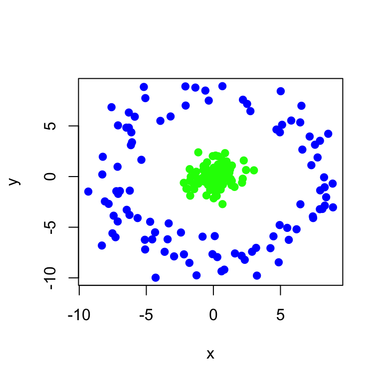

```r
clust1 = data.frame(x=rnorm(100),y=rnorm(100))
a = runif(100,0,2*pi)
clust2 = data.frame(x=8*cos(a) + rnorm(100),y=8*sin(a) + rnorm(100))
plot(clust2,col='blue',pch=19); points(clust1,col='green',pch=19)
```

## Pathological example

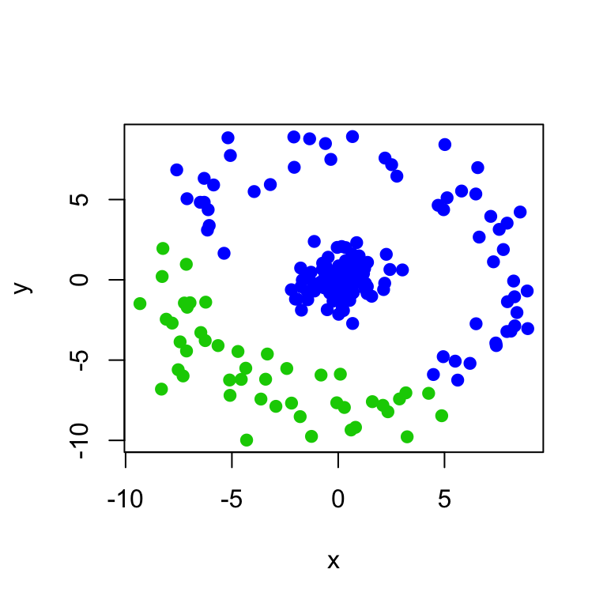

```r
dat = rbind(clust1,clust2)
kk = kmeans(dat,centers=2)
plot(dat,col=(kk$clust+2),pch=19)
```

## Samsung Galaxy S3

[figure not shown]

http://www.samsung.com/global/galaxys3/

## Samsung Data

[figure not shown]

http://archive.ics.uci.edu/ml/datasets/Human+Activity+Recognition+Using+Smartphones

## Slightly processed data

Samsung data file

```r
load("data/samsungData.rda")
names(samsungData)[1:12]
```

```
##  [1] "tBodyAcc-mean()-X" "tBodyAcc-mean()-Y" "tBodyAcc-mean()-Z"
##  [4] "tBodyAcc-std()-X"  "tBodyAcc-std()-Y"  "tBodyAcc-std()-Z"
##  [7] "tBodyAcc-mad()-X"  "tBodyAcc-mad()-Y"  "tBodyAcc-mad()-Z"
## [10] "tBodyAcc-max()-X"  "tBodyAcc-max()-Y"  "tBodyAcc-max()-Z"
```

```r
table(samsungData$activity)
```

```
##
##   laying  sitting standing     walk walkdown   walkup
##     1407     1286     1374     1226      986     1073
```

## Plotting average acceleration for first subject

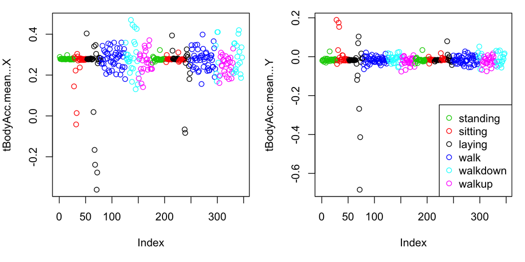

```r
par(mfrow = c(1, 2), mar = c(5, 4, 1, 1))
samsungData <- transform(samsungData, activity = factor(activity))
sub1 <- subset(samsungData, subject == 1)
plot(sub1[, 1], col = sub1$activity, ylab = names(sub1)[1])
plot(sub1[, 2], col = sub1$activity, ylab = names(sub1)[2])
legend("bottomright", legend = unique(sub1$activity), col = unique(sub1$activity),
    pch = 1)
```

## Clustering based just on average acceleration

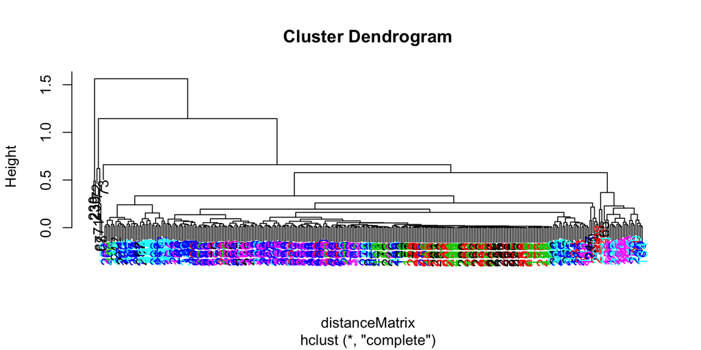

```r
source("myplclust.R")
distanceMatrix <- dist(sub1[,1:3])
hclustering <- hclust(distanceMatrix)
myplclust(hclustering, lab.col = unclass(sub1$activity))
```

## Plotting max acceleration for the first subject

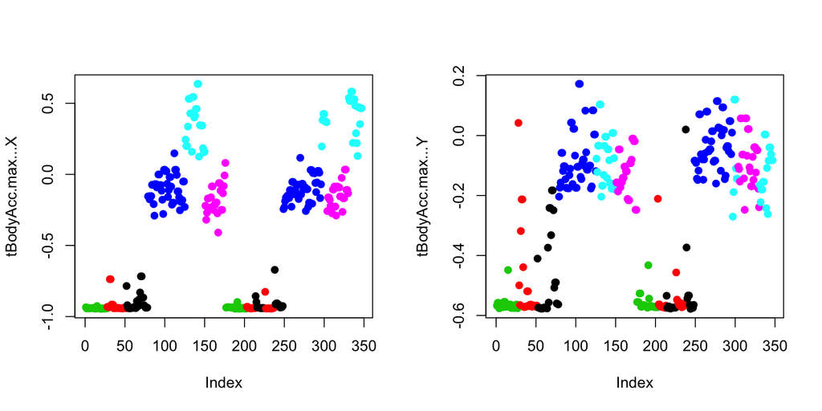

```r
par(mfrow=c(1,2))
plot(sub1[,10],pch=19,col=sub1$activity,ylab=names(sub1)[10])
plot(sub1[,11],pch=19,col = sub1$activity,ylab=names(sub1)[11])
```

## Clustering based on maximum acceleration

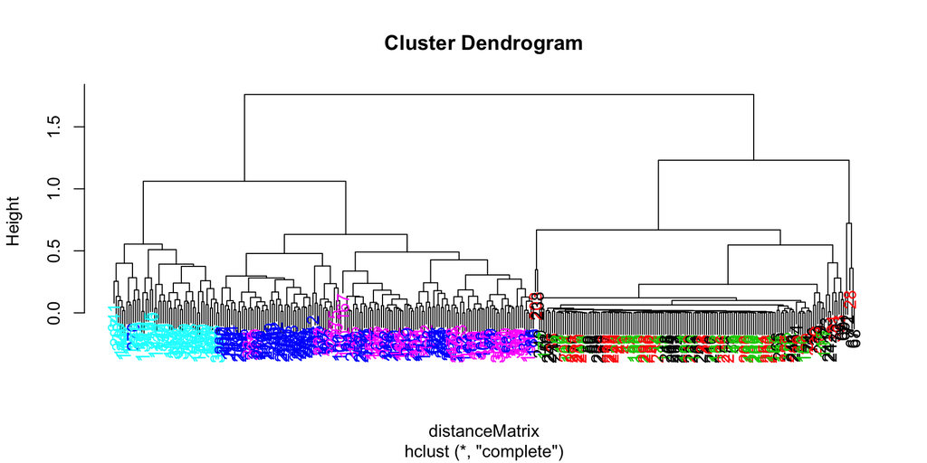

```r
source("myplclust.R")
distanceMatrix <- dist(sub1[,10:12])
hclustering <- hclust(distanceMatrix)
myplclust(hclustering,lab.col=unclass(sub1$activity))
```

## Singular Value Decomposition

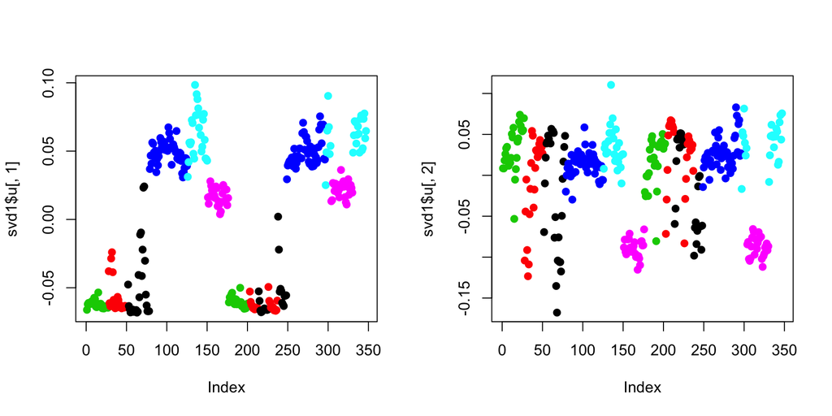

```r
svd1 = svd(scale(sub1[, -c(562, 563)]))
par(mfrow = c(1, 2))
plot(svd1$u[, 1], col = sub1$activity, pch = 19)
plot(svd1$u[, 2], col = sub1$activity, pch = 19)
```

## Find maximum contributor

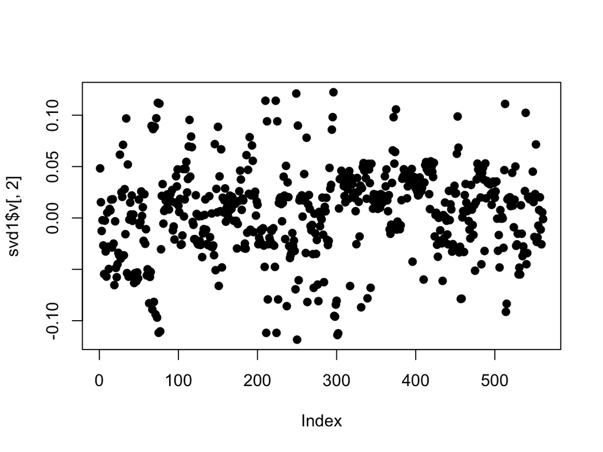

```r
plot(svd1$v[, 2], pch = 19)
```

## New clustering with maximum contributer

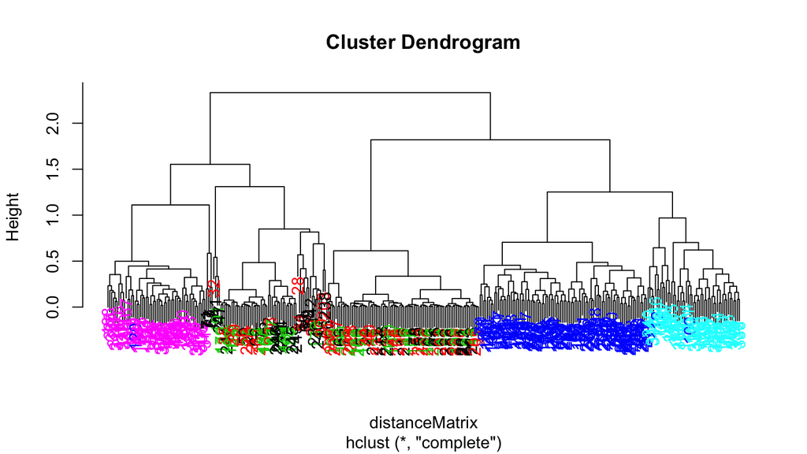

```r
maxContrib <- which.max(svd1$v[, 2])
distanceMatrix <- dist(sub1[, c(10:12, maxContrib)])
hclustering <- hclust(distanceMatrix)
myplclust(hclustering, lab.col = unclass(sub1$activity))
```

## New clustering with maximum contributer

```r
names(samsungData)[maxContrib]
```

```
## [1] "fBodyAcc.meanFreq...Z"
```

## K-means clustering (nstart=1, first try)

```r
kClust <- kmeans(sub1[,-c(562,563)],centers=6)
table(kClust$cluster,sub1$activity)
```

```
##
##     laying sitting standing walk walkdown walkup
##   1      0       0        0    0       23      0
##   2      0       0        0    0       26      0
##   3      0       0        0   95        0      0
##   4     27      37       51    0        0      0
##   5      3       0        0    0        0     53
##   6     20      10        2    0        0      0
```

## K-means clustering (nstart=1, second try)

```r
kClust <- kmeans(sub1[, -c(562, 563)], centers = 6, nstart = 1)
table(kClust$cluster, sub1$activity)
```

```
##
##     laying sitting standing walk walkdown walkup
##   1      3       0        0    0        0     53
##   2     29       0        0    0        0      0
##   3      0       0        0    0       49      0
##   4      0       0        0   95        0      0
##   5      0      37       51    0        0      0
##   6     18      10        2    0        0      0
```

## K-means clustering (nstart=100, first try)

```r
kClust <- kmeans(sub1[,-c(562,563)],centers=6,nstart=100)
table(kClust$cluster,sub1$activity)
```

```
##
##     laying sitting standing walk walkdown walkup
##   1     18      10        2    0        0      0
##   2      0       0        0   95        0      0
##   3      0       0        0    0       49      0
##   4     29       0        0    0        0      0
##   5      0      37       51    0        0      0
##   6      3       0        0    0        0     53
```

## K-means clustering (nstart=100, second try)

```r
kClust <- kmeans(sub1[, -c(562, 563)], centers = 6, nstart = 100)
table(kClust$cluster, sub1$activity)
```

```
##
##     laying sitting standing walk walkdown walkup
##   1      0       0        0    0       49      0
##   2      3       0        0    0        0     53
##   3      0      37       51    0        0      0
##   4      0       0        0   95        0      0
##   5     18      10        2    0        0      0
##   6     29       0        0    0        0      0
```

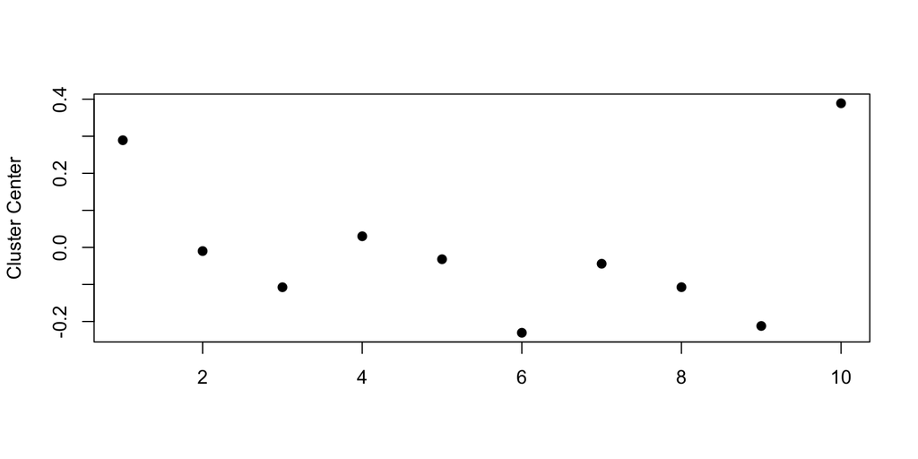

```r
plot(kClust$center[1, 1:10], pch = 19, ylab = "Cluster Center", xlab = "")
```

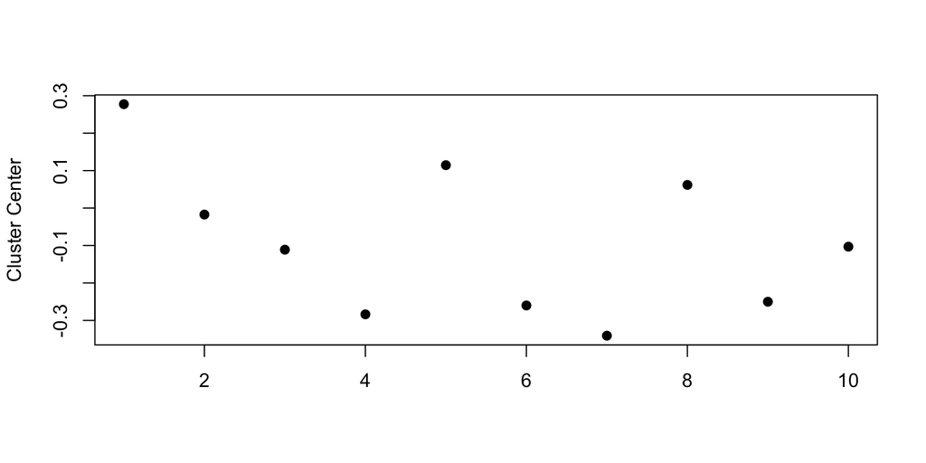

```r
plot(kClust$center[4,1:10],pch=19,ylab="Cluster Center",xlab="")
```

## Clustering wrap up

- Useful for exploring multivariate relationships
- Things that have a bigger than expected impact
  - Scaling
  - Outliers
  - Starting values (k-means)
- Selecting the number of clusters is an "openish" problem.
- Usually there is a local maxima/minima in the tuning parameter

## Clustering wrap up

- Better to visualize!
- As always when the model is (approximately) true you get nice properties from model based approaches
- Clusters must be interpreted and are often very hard to interpret.

## Further resources

- Sources of lecture notes
- http://stat.ethz.ch/education/semesters/SS_2006/CompStat/sk-ch2.pdf
- http://www.cbcb.umd.edu/~hcorrada/PracticalML/
- [Rafa's Distances and Clustering Video](http://www.youtube.com/watch?v=wQhVWUcXM0A)
- [Elements of statistical learning](http://www-stat.stanford.edu/~tibs/ElemStatLearn/)
- [Vadim's lecture notes](https://dl.dropboxusercontent.com/u/7710864/jhsph753/lectures/vadim.pdf)
- http://www.public.iastate.edu/~maitra/stat501/lectures/ModelBasedClustering.pdf
- http://www.ics.uci.edu/~smyth/courses/cs274/readings/fraley_raftery.pdf